# Machine Learning Record

The confidence 95% interval

```r
predict(lm.fit, data.frame(horsepower = c(85)), interval ="confidence")
```

```
##        fit    lwr      upr
## 1 26.51906 25.973 27.06512
```

The 95% prediction interval

```r
predict(lm.fit, data.frame(horsepower = c(85)), interval ="prediction")
```

```
##        fit      lwr      upr
## 1 26.51906 16.85857 36.17954
```

**(b) Plot the response and the predictor. Use the abline() function to display the least squares regression line.**

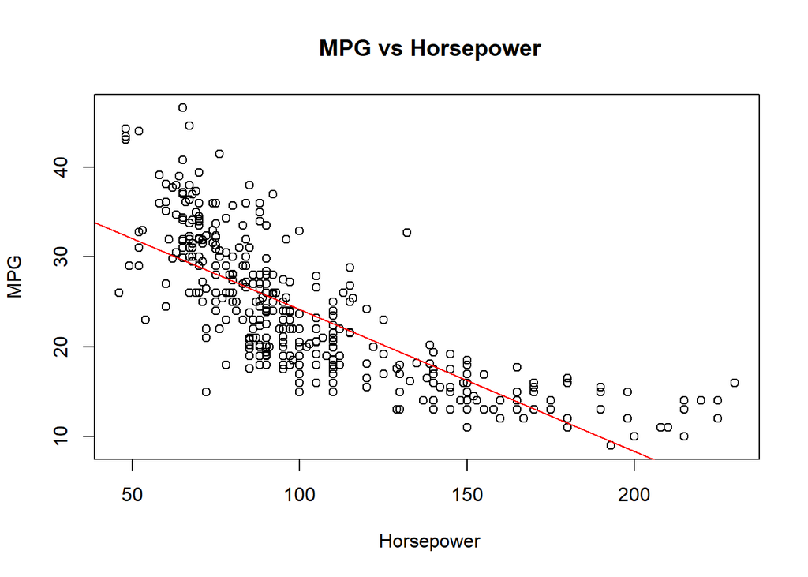

```r
plot(Auto$mpg~Auto$horsepower, main =" MPG vs Horsepower", xlab = " Horsepower", ylab ="MPG")
abline(coef = coef(lm.fit), col ="red")
```

**(c) Use the plot() function to produce diagnostic plots of the least squares regression fit. Comment on any problems you see with the fit.**

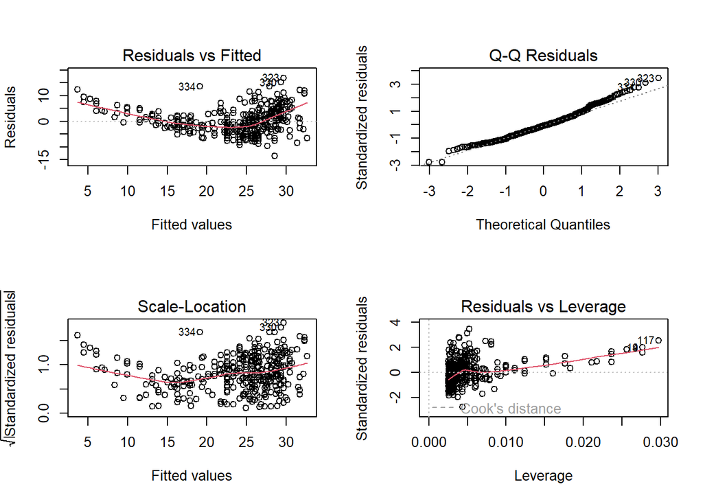

```r
 par(mfrow=c(2,2))
 plot(lm.fit)
```

**4.This question should be answered using the Carseats data set.**

```r
?Carseats
```

```
## starting httpd help server ... done
```

```r
head(Carseats)
```

```
##   Sales CompPrice Income Advertising Population Price ShelveLoc Age Education
## 1  9.50       138     73          11        276   120       Bad  42        17
## 2 11.22       111     48          16        260    83      Good  65        10
## 3 10.06       113     35          10        269    80    Medium  59        12
## 4  7.40       117    100           4        466    97    Medium  55        14
## 5  4.15       141     64           3        340   128       Bad  38        13
## 6 10.81       124    113          13        501    72       Bad  78        16
##   Urban  US
## 1   Yes Yes
## 2   Yes Yes
## 3   Yes Yes
## 4   Yes Yes
## 5   Yes  No
## 6    No Yes
```

```r
str(Carseats)
```

```
## 'data.frame':    400 obs. of  11 variables:
##  $ Sales      : num  9.5 11.22 10.06 7.4 4.15 ...
##  $ CompPrice  : num  138 111 113 117 141 124 115 136 132 132 ...
##  $ Income     : num  73 48 35 100 64 113 105 81 110 113 ...
##  $ Advertising: num  11 16 10 4 3 13 0 15 0 0 ...
##  $ Population : num  276 260 269 466 340 501 45 425 108 131 ...
##  $ Price      : num  120 83 80 97 128 72 108 120 124 124 ...
##  $ ShelveLoc  : Factor w/ 3 levels "Bad","Good","Medium": 1 2 3 3 1 1 3 2 3 3 ...
##  $ Age        : num  42 65 59 55 38 78 71 67 76 76 ...
##  $ Education  : num  17 10 12 14 13 16 15 10 10 17 ...
##  $ Urban      : Factor w/ 2 levels "No","Yes": 2 2 2 2 2 1 2 2 1 1 ...
##  $ US         : Factor w/ 2 levels "No","Yes": 2 2 2 2 1 2 1 2 1 2 ...
```

**(a) Fit a multiple regression model to predict Sales using Price, Urban, and US.**

```r
lm.fit = lm(Sales ~ Price+Urban+US, data= Carseats)
```

```r
summary(lm.fit)
```

[output not shown]

**(b) Provide an interpretation of each coefficient in the model. Be careful—some of the variables in the model are qualitative!**

*Interpretation* When price increases by $1000 and other predictors are held constant, sales decrease by 54.459 unit sales. In otherwords, when price increases by $1000, the number of carseats sold decrease by 54,459.

A store’s sale is not affected by whether or not it is in a Urban area.

A store in the US sales 1200 more carseats (in average) than a store that is abroad.